# **Nowoczesne raportowanie zarządcze z wykorzystaniem AI i narzędzi data science**

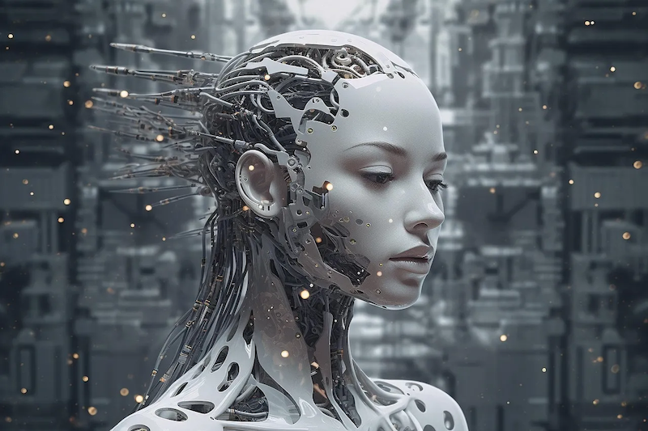

# **SQL i Bazy Danych**

Shareo, Warszawa 16-17 październik 2025

Daniel Wójcik, MBA

## Biblioteki

```python
import pandas as pd
import numpy as np
import pathlib
from pathlib import Path
import os
import datetime

pd.set_option("display.max_rows", None)
pd.options.display.max_colwidth=70
pd.options.display.precision=2
pd.options.display.max_columns=50
pd.options.display.float_format='{0:,.2f}'.format

DATA = pathlib.Path().resolve().parent / 'DATA'
```

## PostgreSQL — charakterystyka i znaczenie

**PostgreSQL** to relacyjna baza danych klasy enterprise, **open-source**, w pełni zgodna z SQL, posiadająca:

- typy danych złożonych (JSON, array, hstore),
- wsparcie dla funkcji analitycznych, CTE, okien (window functions),
- transakcje ACID,
- rozbudowane możliwości integracji (Python, R, BI tools, ETL, Airflow),
- oraz bardzo dobrą wydajność dla raportów i analiz OLAP (w połączeniu z materializowanymi widokami i indeksami BRIN/GiST).

W środowiskach **data lakehouse i raportowania zarządczego** PostgreSQL pełni często **podwójną rolę**:

1. **Źródła danych (Bronze)** — import danych operacyjnych (np. ERP, CRM, system finansowy).
2. **Magazynu raportowego (Gold)** — gotowe zestawienia, agregaty, KPI i dane prezentowane dashboardom (Streamlit, Dash, Power BI).

## PostgreSQL — Instalacja

[figure not shown]

```
https://www.postgresql.org/download/
https://www.psycopg.org/install/
pip install 'psycopg[binary]'
```

## Dbeaver

[figure not shown]

```
https://dbeaver.io/download/
```

## SQL Alchemy

SQLAlchemy to potężna biblioteka w języku Python, służąca do obsługi baz danych relacyjnych w sposób zarówno niskopoziomowy (SQL), jak i wysokopoziomowy (ORM – Object Relational Mapping). Pozwala pisać kod, który komunikuje się z bazą danych w sposób abstrakcyjny i przenośny, bez konieczności używania bezpośrednio zapytań SQL — choć SQLAlchemy w pełni wspiera ich użycie, gdy jest to potrzebne.

🧩 Dwa główne poziomy SQLAlchemy

1. Core (SQL Expression Language)

To niższy poziom biblioteki – działa bezpośrednio na strukturze SQL. Dzięki niemu można: • tworzyć tabele i schematy baz danych, • generować zapytania SQL w sposób programistyczny (bez pisania ich jako tekst), • łączyć się z różnymi silnikami baz danych (PostgreSQL, SQLite, MySQL, Oracle, MSSQL itd.), • wykonywać zapytania bez użycia ORM.

2. ORM (Object Relational Mapper)

To wyższy poziom abstrakcji, w którym tabele odwzorowuje się na klasy Pythona. Każdy rekord w bazie to instancja klasy, a kolumny to atrybuty tej klasy.

⚙️ Najważniejsze zalety SQLAlchemy

- ✅ Abstrakcja bazy danych – ten sam kod działa z różnymi silnikami (np. SQLite lokalnie, PostgreSQL w produkcji).
- ✅ Bezpieczeństwo – unika błędów typu SQL injection, bo zapytania są parametryzowane.
- ✅ Elastyczność – można używać zarówno ORM, jak i czystego SQL-a.
- ✅ Transakcje i sesje – wbudowany system zarządzania transakcjami i spójnością danych.
- ✅ Integracja z frameworkami – np. Flask, FastAPI, Django (częściowo).

```
https://docs.sqlalchemy.org/en/20/intro.html#installation
pip install SQLAlchemy
```

```python
from sqlalchemy import create_engine
```

```python
engine = create_engine("postgresql+psycopg://postgres:postgres@localhost:5433/postgres")
```

```python
df=pd.read_csv(DATA / 'DataSet.csv', sep=',', encoding='utf-8')
```

```python
df.to_sql("DataSet", engine, schema="public", if_exists="replace")
```

```
-1
```

```python
t_sql='''
SELECT *
FROM public."DataSet"
WHERE "Region" = 'Region Centralny'
  AND "Data_transakcji" < '2026-01-30';
'''
```

```python
df_sql = pd.read_sql(t_sql, engine)
```

```python
df_sql.head()
```

|  | index | Unnamed: 0 | Data_transakcji | Region | Miasto | Klient | Płeć | PESEL | Data_urodzenia | Wiek | Wartość | Segment | Kanał_grupa | Kanał | Warstwa | Usługa |
| --- | --- | --- | --- | --- | --- | --- | --- | --- | --- | --- | --- | --- | --- | --- | --- | --- |
| 0 | 55 | 55 | 2026-01-08 | Region Centralny | Warszawa | Apolonia Wasilewicz | K | 92052876322 | 1992-05-28 | 34 | 2,054.79 | Premium | Kanały afiliacyjne i rekomendacje | Program partnerski dla lekarzy i dietetyków | Data Layer | AI-powered insights dla ubezpieczycieli i korporacji |
| 1 | 70 | 70 | 2026-01-07 | Region Centralny | Łódź | Julian Powała | K | 77122418806 | 1977-12-24 | 49 | 2,920.00 | Standard | Kanały afiliacyjne i rekomendacje | Program rekomendacyjny dla pacjentów | Data Layer | AI-powered insights dla ubezpieczycieli i korporacji |
| 2 | 96 | 96 | 2026-01-16 | Region Centralny | Siedlce | Leonard Godzwon | K | 89042056862 | 1989-04-20 | 37 | 2,595.11 | Standard | Kanały własne (direct) | Strona internetowa i blog edukacyjny | Data Layer | Baza danych biomedycznych i predykcyjnych modeli AI |
| 3 | 138 | 138 | 2026-01-10 | Region Centralny | Radom | Marek Matyszczak | M | 46111519596 | 1946-11-15 | 80 | 2,915.09 | Standard | Partnerstwa strategiczne | Współpraca z klinikami, siłowniami i SPA | Ecosystem Layer | Nutraceutyki i suplementy funkcjonalne |
| 4 | 288 | 288 | 2026-01-11 | Region Centralny | Siedlce | Anastazja Rogal | K | 96071962569 | 1996-07-19 | 30 | 2,009.71 | Premium | Kanały własne (direct) | Aplikacja mobilna (AI Health Coach) | Scalable Layer | Telekonsultacje i monitoring pacjentów |

```python
df_sql.describe()
```

|  | index | Unnamed: 0 | PESEL | Wiek | Wartość |
| --- | --- | --- | --- | --- | --- |
| count | 140.00 | 140.00 | 140.00 | 140.00 | 140.00 |
| mean | 5,043.84 | 5,043.84 | 63,319,837,660.33 | 49.91 | 2,513.64 |
| std | 2,920.85 | 2,920.85 | 27,493,963,510.70 | 17.62 | 296.04 |
| min | 55.00 | 55.00 | 231,557,500.00 | 19.00 | 2,004.89 |
| 25% | 2,479.25 | 2,479.25 | 53,550,503,628.00 | 34.00 | 2,262.27 |
| 50% | 5,305.50 | 5,305.50 | 68,066,157,316.00 | 51.00 | 2,528.97 |
| 75% | 7,652.50 | 7,652.50 | 83,063,064,814.00 | 64.00 | 2,801.25 |
| max | 9,922.00 | 9,922.00 | 99,031,040,114.00 | 81.00 | 2,987.61 |

```python
df_sql.info()
```

```
<class 'pandas.core.frame.DataFrame'>
RangeIndex: 140 entries, 0 to 139
Data columns (total 16 columns):
 #   Column           Non-Null Count  Dtype
---  ------           --------------  -----
 0   index            140 non-null    int64
 1   Unnamed: 0       140 non-null    int64
 2   Data_transakcji  140 non-null    object
 3   Region           140 non-null    object
 4   Miasto           140 non-null    object
 5   Klient           140 non-null    object
 6   Płeć             140 non-null    object
 7   PESEL            140 non-null    int64
 8   Data_urodzenia   140 non-null    object
 9   Wiek             140 non-null    int64
 10  Wartość          140 non-null    float64
 11  Segment          140 non-null    object
 12  Kanał_grupa      140 non-null    object
 13  Kanał            140 non-null    object
 14  Warstwa          140 non-null    object
 15  Usługa           140 non-null    object
dtypes: float64(1), int64(4), object(11)
memory usage: 17.6+ KB
```

## PSYCOPG

- Oficjalny **adapter PostgreSQL dla Pythona**, zgodny ze standardem DB-API 2.0.
- Umożliwia bezpośrednie wysyłanie zapytań SQL, pobieranie wyników, wykonywanie transakcji.
- Wykorzystywany przez biblioteki wyższego poziomu, np. SQLAlchemy, Pandas (read_sql), Airflow, Django ORM.
- Obsługuje **parametryzację zapytań** (bezpieczne wstawianie danych), **transakcje**, **kursory**, **COPY** (hurtowe przesyły danych).

```python
import psycopg
```

```python
# Dane połączenia
conn = psycopg.connect(
    dbname="postgres",
    user="postgres",
    password="postgres",
    host="localhost",
    port="5433"
)

# Utworzenie kursora
cur = conn.cursor()

# Wykonanie prostego zapytania
cur.execute("SELECT version();")

# Pobranie wyniku
version = cur.fetchone()
print("Wersja PostgreSQL:", version)

# Zamknięcie połączenia
cur.close()
conn.close()
```

```
Wersja PostgreSQL: ('PostgreSQL 18.0 on x86_64-apple-darwin23.6.0, compiled by Apple clang version 16.0.0 (clang-1600.0.26.6), 64-bit',)
```

```python
conn = psycopg.connect(
    dbname="postgres",
    user="postgres",
    password="postgres",
    host="localhost",
    port="5433"
)

# Utworzenie kursora
cur = conn.cursor()

# Tworzenie tabeli (jeśli nie istnieje)
cur.execute("""
CREATE TABLE IF NOT EXISTS employees (
    id SERIAL PRIMARY KEY,
    name TEXT,
    position TEXT,
    salary NUMERIC
);
""")

# Wstawienie pojedynczego rekordu
cur.execute(
    "INSERT INTO employees (name, position, salary) VALUES (%s, %s, %s)",
    ("Anna Nowak", "Data Analyst", 8500)
)

# Zatwierdzenie transakcji
conn.commit()
cur.close()
conn.close()
```

```python
from psycopg import OperationalError

def create_connection(db_name, db_user, db_password, db_host, db_port):
    connection = None
    try:
        connection = psycopg.connect(
            dbname=db_name,
            user=db_user,
            password=db_password,
            host=db_host,
            port=db_port,
        )
        print("Connection to PostgreSQL DB successful")
    except OperationalError as e:
        print(f"The error '{e}' occurred")
    return connection
```

```python
connection = create_connection("postgres", "postgres", "postgres", "127.0.0.1", "5433")
```

```
Connection to PostgreSQL DB successful
```

```python
from psycopg import Error

def execute_query(connection, query):
    try:
        with connection.cursor() as cursor:
            cursor.execute(query)
            connection.commit()
            print("Query executed successfully")
    except Error as e:
        print(f"The error '{e}' occurred")
```